# Risk Factor Analysis

## Outcome Variable

**Outcome Variable:** haz

## Predictor Variables

**Intervention Variable:** predfeed36

**Adjustment Set:**

- arm
- sex
- month
- brthmon
- W_mage
- meducyrs
- feducyrs
- hhwealth_quart
- hfoodsec
- W_mhtcm
- W_mwtkg
- W_mbmi
- vagbrth
- W_gagebrth
- W_birthwt
- W_birthlen
- W_nrooms
- W_nchldlt5
- W_parity
- impfloor
- impsan
- safeh20
- delta_W_mage
- delta_meducyrs
- delta_feducyrs
- delta_hhwealth_quart
- delta_hfoodsec
- delta_W_mhtcm
- delta_W_mwtkg
- delta_W_mbmi
- delta_vagbrth
- delta_W_gagebrth
- delta_W_birthwt
- delta_W_birthlen
- delta_W_nrooms
- delta_W_nchldlt5
- delta_W_parity
- delta_impfloor
- delta_impsan
- delta_safeh20

## Stratifying Variables

The analysis was stratified on these variable(s):

- agecat
- studyid
- country

## Data Summary

| agecat | studyid | country | predfeed36 | n_cell | n | outcome_variable |
| --- | --- | --- | --- | --- | --- | --- |
| Birth | ki0047075b-MAL-ED | BANGLADESH | 1 | 72 | 221 | haz |
| Birth | ki0047075b-MAL-ED | BANGLADESH | 0 | 149 | 221 | haz |
| Birth | ki0047075b-MAL-ED | BRAZIL | 1 | 8 | 65 | haz |
| Birth | ki0047075b-MAL-ED | BRAZIL | 0 | 57 | 65 | haz |
| Birth | ki0047075b-MAL-ED | INDIA | 1 | 4 | 42 | haz |
| Birth | ki0047075b-MAL-ED | INDIA | 0 | 38 | 42 | haz |
| Birth | ki0047075b-MAL-ED | NEPAL | 1 | 1 | 26 | haz |
| Birth | ki0047075b-MAL-ED | NEPAL | 0 | 25 | 26 | haz |
| Birth | ki0047075b-MAL-ED | PERU | 1 | 58 | 223 | haz |
| Birth | ki0047075b-MAL-ED | PERU | 0 | 165 | 223 | haz |
| Birth | ki0047075b-MAL-ED | SOUTH AFRICA | 1 | 2 | 105 | haz |
| Birth | ki0047075b-MAL-ED | SOUTH AFRICA | 0 | 103 | 105 | haz |
| Birth | ki0047075b-MAL-ED | TANZANIA, UNITED REPUBLIC OF | 1 | 0 | 119 | haz |
| Birth | ki0047075b-MAL-ED | TANZANIA, UNITED REPUBLIC OF | 0 | 119 | 119 | haz |
| Birth | ki1000109-EE | PAKISTAN | 1 | 3 | 7 | haz |
| Birth | ki1000109-EE | PAKISTAN | 0 | 4 | 7 | haz |
| Birth | ki1113344-GMS-Nepal | NEPAL | 1 | 422 | 526 | haz |
| Birth | ki1113344-GMS-Nepal | NEPAL | 0 | 104 | 526 | haz |
| Birth | kiGH5241-JiVitA-3 | BANGLADESH | 1 | 8334 | 10681 | haz |
| Birth | kiGH5241-JiVitA-3 | BANGLADESH | 0 | 2347 | 10681 | haz |
| Birth | kiGH5241-JiVitA-4 | BANGLADESH | 1 | 1999 | 2517 | haz |
| Birth | kiGH5241-JiVitA-4 | BANGLADESH | 0 | 518 | 2517 | haz |
| 6 months | ki0047075b-MAL-ED | BANGLADESH | 1 | 81 | 240 | haz |
| 6 months | ki0047075b-MAL-ED | BANGLADESH | 0 | 159 | 240 | haz |
| 6 months | ki0047075b-MAL-ED | BRAZIL | 1 | 25 | 209 | haz |
| 6 months | ki0047075b-MAL-ED | BRAZIL | 0 | 184 | 209 | haz |
| 6 months | ki0047075b-MAL-ED | INDIA | 1 | 17 | 233 | haz |
| 6 months | ki0047075b-MAL-ED | INDIA | 0 | 216 | 233 | haz |
| 6 months | ki0047075b-MAL-ED | NEPAL | 1 | 8 | 235 | haz |
| 6 months | ki0047075b-MAL-ED | NEPAL | 0 | 227 | 235 | haz |
| 6 months | ki0047075b-MAL-ED | PERU | 1 | 72 | 272 | haz |
| 6 months | ki0047075b-MAL-ED | PERU | 0 | 200 | 272 | haz |
| 6 months | ki0047075b-MAL-ED | SOUTH AFRICA | 1 | 3 | 250 | haz |
| 6 months | ki0047075b-MAL-ED | SOUTH AFRICA | 0 | 247 | 250 | haz |
| 6 months | ki0047075b-MAL-ED | TANZANIA, UNITED REPUBLIC OF | 1 | 5 | 243 | haz |
| 6 months | ki0047075b-MAL-ED | TANZANIA, UNITED REPUBLIC OF | 0 | 238 | 243 | haz |
| 6 months | ki1000109-EE | PAKISTAN | 1 | 4 | 9 | haz |
| 6 months | ki1000109-EE | PAKISTAN | 0 | 5 | 9 | haz |
| 6 months | ki1000304b-SAS-FoodSuppl | INDIA | 1 | 0 | 168 | haz |
| 6 months | ki1000304b-SAS-FoodSuppl | INDIA | 0 | 168 | 168 | haz |
| 6 months | ki1113344-GMS-Nepal | NEPAL | 1 | 422 | 527 | haz |
| 6 months | ki1113344-GMS-Nepal | NEPAL | 0 | 105 | 527 | haz |
| 6 months | ki1148112-LCNI-5 | MALAWI | 1 | 47 | 272 | haz |
| 6 months | ki1148112-LCNI-5 | MALAWI | 0 | 225 | 272 | haz |
| 6 months | kiGH5241-JiVitA-3 | BANGLADESH | 1 | 6593 | 8552 | haz |
| 6 months | kiGH5241-JiVitA-3 | BANGLADESH | 0 | 1959 | 8552 | haz |
| 6 months | kiGH5241-JiVitA-4 | BANGLADESH | 1 | 3253 | 4185 | haz |
| 6 months | kiGH5241-JiVitA-4 | BANGLADESH | 0 | 932 | 4185 | haz |
| 24 months | ki0047075b-MAL-ED | BANGLADESH | 1 | 69 | 212 | haz |
| 24 months | ki0047075b-MAL-ED | BANGLADESH | 0 | 143 | 212 | haz |
| 24 months | ki0047075b-MAL-ED | BRAZIL | 1 | 20 | 169 | haz |
| 24 months | ki0047075b-MAL-ED | BRAZIL | 0 | 149 | 169 | haz |
| 24 months | ki0047075b-MAL-ED | INDIA | 1 | 17 | 224 | haz |
| 24 months | ki0047075b-MAL-ED | INDIA | 0 | 207 | 224 | haz |
| 24 months | ki0047075b-MAL-ED | NEPAL | 1 | 8 | 227 | haz |
| 24 months | ki0047075b-MAL-ED | NEPAL | 0 | 219 | 227 | haz |
| 24 months | ki0047075b-MAL-ED | PERU | 1 | 53 | 201 | haz |
| 24 months | ki0047075b-MAL-ED | PERU | 0 | 148 | 201 | haz |
| 24 months | ki0047075b-MAL-ED | SOUTH AFRICA | 1 | 3 | 235 | haz |
| 24 months | ki0047075b-MAL-ED | SOUTH AFRICA | 0 | 232 | 235 | haz |
| 24 months | ki0047075b-MAL-ED | TANZANIA, UNITED REPUBLIC OF | 1 | 4 | 213 | haz |
| 24 months | ki0047075b-MAL-ED | TANZANIA, UNITED REPUBLIC OF | 0 | 209 | 213 | haz |
| 24 months | ki1000109-EE | PAKISTAN | 1 | 0 | 3 | haz |
| 24 months | ki1000109-EE | PAKISTAN | 0 | 3 | 3 | haz |
| 24 months | ki1113344-GMS-Nepal | NEPAL | 1 | 363 | 446 | haz |
| 24 months | ki1113344-GMS-Nepal | NEPAL | 0 | 83 | 446 | haz |
| 24 months | ki1148112-LCNI-5 | MALAWI | 1 | 34 | 189 | haz |
| 24 months | ki1148112-LCNI-5 | MALAWI | 0 | 155 | 189 | haz |
| 24 months | kiGH5241-JiVitA-3 | BANGLADESH | 1 | 3334 | 4334 | haz |
| 24 months | kiGH5241-JiVitA-3 | BANGLADESH | 0 | 1000 | 4334 | haz |
| 24 months | kiGH5241-JiVitA-4 | BANGLADESH | 1 | 3157 | 4049 | haz |
| 24 months | kiGH5241-JiVitA-4 | BANGLADESH | 0 | 892 | 4049 | haz |

The following strata were considered:

- agecat: 24 months, studyid: ki0047075b-MAL-ED, country: BANGLADESH
- agecat: 24 months, studyid: ki0047075b-MAL-ED, country: BRAZIL
- agecat: 24 months, studyid: ki0047075b-MAL-ED, country: INDIA
- agecat: 24 months, studyid: ki0047075b-MAL-ED, country: NEPAL
- agecat: 24 months, studyid: ki0047075b-MAL-ED, country: PERU
- agecat: 24 months, studyid: ki0047075b-MAL-ED, country: SOUTH AFRICA
- agecat: 24 months, studyid: ki0047075b-MAL-ED, country: TANZANIA, UNITED REPUBLIC OF
- agecat: 24 months, studyid: ki1000109-EE, country: PAKISTAN
- agecat: 24 months, studyid: ki1113344-GMS-Nepal, country: NEPAL
- agecat: 24 months, studyid: ki1148112-LCNI-5, country: MALAWI
- agecat: 24 months, studyid: kiGH5241-JiVitA-3, country: BANGLADESH
- agecat: 24 months, studyid: kiGH5241-JiVitA-4, country: BANGLADESH
- agecat: 6 months, studyid: ki0047075b-MAL-ED, country: BANGLADESH
- agecat: 6 months, studyid: ki0047075b-MAL-ED, country: BRAZIL
- agecat: 6 months, studyid: ki0047075b-MAL-ED, country: INDIA
- agecat: 6 months, studyid: ki0047075b-MAL-ED, country: NEPAL
- agecat: 6 months, studyid: ki0047075b-MAL-ED, country: PERU
- agecat: 6 months, studyid: ki0047075b-MAL-ED, country: SOUTH AFRICA
- agecat: 6 months, studyid: ki0047075b-MAL-ED, country: TANZANIA, UNITED REPUBLIC OF
- agecat: 6 months, studyid: ki1000109-EE, country: PAKISTAN
- agecat: 6 months, studyid: ki1000304b-SAS-FoodSuppl, country: INDIA
- agecat: 6 months, studyid: ki1113344-GMS-Nepal, country: NEPAL
- agecat: 6 months, studyid: ki1148112-LCNI-5, country: MALAWI
- agecat: 6 months, studyid: kiGH5241-JiVitA-3, country: BANGLADESH
- agecat: 6 months, studyid: kiGH5241-JiVitA-4, country: BANGLADESH
- agecat: Birth, studyid: ki0047075b-MAL-ED, country: BANGLADESH
- agecat: Birth, studyid: ki0047075b-MAL-ED, country: BRAZIL
- agecat: Birth, studyid: ki0047075b-MAL-ED, country: INDIA
- agecat: Birth, studyid: ki0047075b-MAL-ED, country: NEPAL
- agecat: Birth, studyid: ki0047075b-MAL-ED, country: PERU
- agecat: Birth, studyid: ki0047075b-MAL-ED, country: SOUTH AFRICA
- agecat: Birth, studyid: ki0047075b-MAL-ED, country: TANZANIA, UNITED REPUBLIC OF
- agecat: Birth, studyid: ki1000109-EE, country: PAKISTAN
- agecat: Birth, studyid: ki1113344-GMS-Nepal, country: NEPAL
- agecat: Birth, studyid: kiGH5241-JiVitA-3, country: BANGLADESH
- agecat: Birth, studyid: kiGH5241-JiVitA-4, country: BANGLADESH

### Dropped Strata

- agecat: Birth, studyid: ki0047075b-MAL-ED, country: INDIA
- agecat: Birth, studyid: ki0047075b-MAL-ED, country: NEPAL
- agecat: Birth, studyid: ki0047075b-MAL-ED, country: SOUTH AFRICA
- agecat: Birth, studyid: ki0047075b-MAL-ED, country: TANZANIA, UNITED REPUBLIC OF
- agecat: Birth, studyid: ki1000109-EE, country: PAKISTAN
- agecat: 6 months, studyid: ki0047075b-MAL-ED, country: SOUTH AFRICA
- agecat: 6 months, studyid: ki1000109-EE, country: PAKISTAN
- agecat: 6 months, studyid: ki1000304b-SAS-FoodSuppl, country: INDIA
- agecat: 24 months, studyid: ki0047075b-MAL-ED, country: SOUTH AFRICA
- agecat: 24 months, studyid: ki0047075b-MAL-ED, country: TANZANIA, UNITED REPUBLIC OF
- agecat: 24 months, studyid: ki1000109-EE, country: PAKISTAN

## Methods Detail

We’re interested in the causal parameters $E[Y_a]$ for all values of $a \in \mathcal{A}$. These parameters represent the mean outcome if, possibly contrary to fact, we intervened to set all units to have $A=a$. Under the randomization and positivity assumptions, these are identified by the statistical parameters $\psi_a=E_W[E_{Y|A,W}(Y|A=a,W)]$. In addition, we’re interested in the mean of $Y$, $E[Y]$ under no intervention (the observed mean). We will estimate these parameters by using SuperLearner to fit the relevant likelihood factors – $E_{Y|A,W}(Y|A=a,W)$ and $p(A=a|W)$, and then updating our likelihood fit using a joint TMLE.

For unadjusted analyses ($W=\{\}$), initial likelihoods were estimated using Lrnr_glm to estimate the simple $E(Y|A)$ and Lrnr_mean to estimate $p(A)$. For adjusted analyses, a small library containing Lrnr_glmnet, Lrnr_xgboost, and Lrnr_mean was used.

# Results Detail

## Results Plots

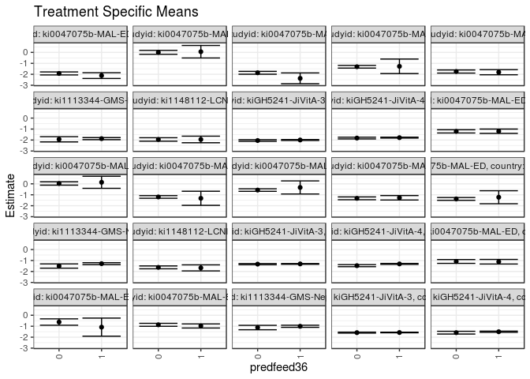

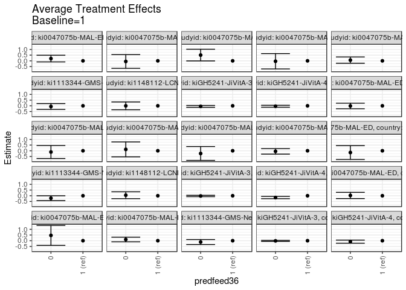

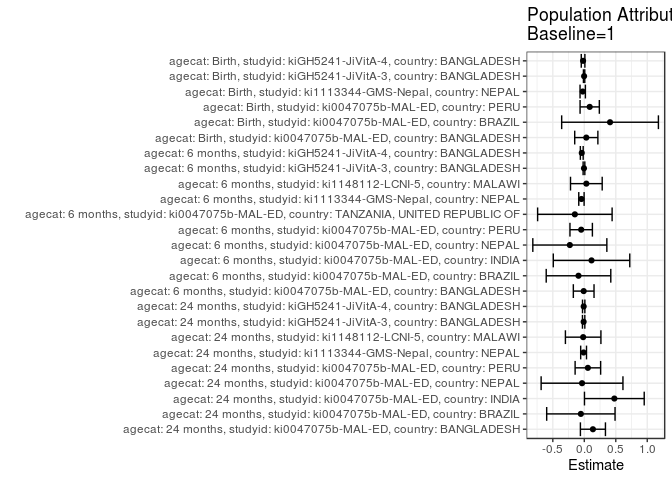

## Results Table

### Parameter: TSM

| agecat | studyid | country | intervention_level | baseline_level | estimate | ci_lower | ci_upper |
| --- | --- | --- | --- | --- | --- | --- | --- |
| Birth | ki0047075b-MAL-ED | BANGLADESH | 1 | NA | -1.1120603 | -1.3201316 | -0.9039890 |
| Birth | ki0047075b-MAL-ED | BANGLADESH | 0 | NA | -1.0869598 | -1.2615276 | -0.9123921 |
| Birth | ki0047075b-MAL-ED | BRAZIL | 1 | NA | -1.0850000 | -1.9106873 | -0.2593127 |
| Birth | ki0047075b-MAL-ED | BRAZIL | 0 | NA | -0.6185965 | -0.9082545 | -0.3289385 |
| Birth | ki0047075b-MAL-ED | PERU | 1 | NA | -0.9772725 | -1.1631078 | -0.7914371 |
| Birth | ki0047075b-MAL-ED | PERU | 0 | NA | -0.8712048 | -1.0063670 | -0.7360426 |
| Birth | ki1113344-GMS-Nepal | NEPAL | 1 | NA | -1.0050089 | -1.1011161 | -0.9089017 |
| Birth | ki1113344-GMS-Nepal | NEPAL | 0 | NA | -1.1205800 | -1.3218422 | -0.9193178 |
| Birth | kiGH5241-JiVitA-3 | BANGLADESH | 1 | NA | -1.5732880 | -1.6012763 | -1.5452998 |
| Birth | kiGH5241-JiVitA-3 | BANGLADESH | 0 | NA | -1.5858312 | -1.6308116 | -1.5408508 |
| Birth | kiGH5241-JiVitA-4 | BANGLADESH | 1 | NA | -1.5041522 | -1.5576176 | -1.4506868 |
| Birth | kiGH5241-JiVitA-4 | BANGLADESH | 0 | NA | -1.5872969 | -1.7134195 | -1.4611743 |
| 6 months | ki0047075b-MAL-ED | BANGLADESH | 1 | NA | -1.1975513 | -1.3939765 | -1.0011261 |
| 6 months | ki0047075b-MAL-ED | BANGLADESH | 0 | NA | -1.2116243 | -1.3598278 | -1.0634208 |
| 6 months | ki0047075b-MAL-ED | BRAZIL | 1 | NA | 0.1395484 | -0.4098192 | 0.6889159 |
| 6 months | ki0047075b-MAL-ED | BRAZIL | 0 | NA | 0.0310878 | -0.1198284 | 0.1820040 |
| 6 months | ki0047075b-MAL-ED | INDIA | 1 | NA | -1.3204650 | -1.9634003 | -0.6775298 |
| 6 months | ki0047075b-MAL-ED | INDIA | 0 | NA | -1.1982394 | -1.3173544 | -1.0791244 |
| 6 months | ki0047075b-MAL-ED | NEPAL | 1 | NA | -0.3325000 | -0.9301243 | 0.2651243 |
| 6 months | ki0047075b-MAL-ED | NEPAL | 0 | NA | -0.5702349 | -0.6852437 | -0.4552262 |
| 6 months | ki0047075b-MAL-ED | PERU | 1 | NA | -1.2736319 | -1.4770989 | -1.0701649 |
| 6 months | ki0047075b-MAL-ED | PERU | 0 | NA | -1.3234899 | -1.4520484 | -1.1949314 |
| 6 months | ki0047075b-MAL-ED | TANZANIA, UNITED REPUBLIC OF | 1 | NA | -1.2240000 | -1.8175386 | -0.6304614 |
| 6 months | ki0047075b-MAL-ED | TANZANIA, UNITED REPUBLIC OF | 0 | NA | -1.3768487 | -1.5024066 | -1.2512909 |
| 6 months | ki1113344-GMS-Nepal | NEPAL | 1 | NA | -1.2883726 | -1.3752294 | -1.2015157 |
| 6 months | ki1113344-GMS-Nepal | NEPAL | 0 | NA | -1.5042371 | -1.6978711 | -1.3106030 |
| 6 months | ki1148112-LCNI-5 | MALAWI | 1 | NA | -1.6723373 | -1.9485263 | -1.3961483 |
| 6 months | ki1148112-LCNI-5 | MALAWI | 0 | NA | -1.6263954 | -1.7580455 | -1.4947452 |
| 6 months | kiGH5241-JiVitA-3 | BANGLADESH | 1 | NA | -1.3102511 | -1.3421750 | -1.2783272 |
| 6 months | kiGH5241-JiVitA-3 | BANGLADESH | 0 | NA | -1.3304369 | -1.3848807 | -1.2759931 |
| 6 months | kiGH5241-JiVitA-4 | BANGLADESH | 1 | NA | -1.3113694 | -1.3529609 | -1.2697779 |
| 6 months | kiGH5241-JiVitA-4 | BANGLADESH | 0 | NA | -1.4709051 | -1.5651686 | -1.3766416 |
| 24 months | ki0047075b-MAL-ED | BANGLADESH | 1 | NA | -2.1155166 | -2.3772694 | -1.8537639 |
| 24 months | ki0047075b-MAL-ED | BANGLADESH | 0 | NA | -1.9187520 | -2.0553715 | -1.7821325 |
| 24 months | ki0047075b-MAL-ED | BRAZIL | 1 | NA | 0.0605050 | -0.5107797 | 0.6317897 |
| 24 months | ki0047075b-MAL-ED | BRAZIL | 0 | NA | 0.0052724 | -0.1757035 | 0.1862483 |
| 24 months | ki0047075b-MAL-ED | INDIA | 1 | NA | -2.3679209 | -2.8611184 | -1.8747234 |
| 24 months | ki0047075b-MAL-ED | INDIA | 0 | NA | -1.8621119 | -1.9920595 | -1.7321643 |
| 24 months | ki0047075b-MAL-ED | NEPAL | 1 | NA | -1.2725000 | -1.9347673 | -0.6102327 |
| 24 months | ki0047075b-MAL-ED | NEPAL | 0 | NA | -1.3095434 | -1.4315531 | -1.1875337 |
| 24 months | ki0047075b-MAL-ED | PERU | 1 | NA | -1.8094046 | -2.0435771 | -1.5752322 |
| 24 months | ki0047075b-MAL-ED | PERU | 0 | NA | -1.7450376 | -1.8872418 | -1.6028334 |
| 24 months | ki1113344-GMS-Nepal | NEPAL | 1 | NA | -1.8720060 | -1.9653876 | -1.7786244 |
| 24 months | ki1113344-GMS-Nepal | NEPAL | 0 | NA | -1.9329350 | -2.1714725 | -1.6943975 |
| 24 months | ki1148112-LCNI-5 | MALAWI | 1 | NA | -1.9472700 | -2.2479688 | -1.6465713 |
| 24 months | ki1148112-LCNI-5 | MALAWI | 0 | NA | -1.9499078 | -2.1087414 | -1.7910742 |
| 24 months | kiGH5241-JiVitA-3 | BANGLADESH | 1 | NA | -1.9967803 | -2.0386509 | -1.9549098 |
| 24 months | kiGH5241-JiVitA-3 | BANGLADESH | 0 | NA | -2.0454895 | -2.1202773 | -1.9707018 |
| 24 months | kiGH5241-JiVitA-4 | BANGLADESH | 1 | NA | -1.7826886 | -1.8255665 | -1.7398107 |
| 24 months | kiGH5241-JiVitA-4 | BANGLADESH | 0 | NA | -1.8212110 | -1.9003905 | -1.7420315 |

### Parameter: E(Y)

| agecat | studyid | country | intervention_level | baseline_level | estimate | ci_lower | ci_upper |
| --- | --- | --- | --- | --- | --- | --- | --- |
| Birth | ki0047075b-MAL-ED | BANGLADESH | NA | NA | -1.0802262 | -1.2151319 | -0.9453206 |
| Birth | ki0047075b-MAL-ED | BRAZIL | NA | NA | -0.6760000 | -0.9521457 | -0.3998543 |
| Birth | ki0047075b-MAL-ED | PERU | NA | NA | -0.8913004 | -1.0115814 | -0.7710195 |
| Birth | ki1113344-GMS-Nepal | NEPAL | NA | NA | -1.0299620 | -1.1192344 | -0.9406896 |
| Birth | kiGH5241-JiVitA-3 | BANGLADESH | NA | NA | -1.5762700 | -1.6018685 | -1.5506716 |
| Birth | kiGH5241-JiVitA-4 | BANGLADESH | NA | NA | -1.5234724 | -1.5733491 | -1.4735957 |
| 6 months | ki0047075b-MAL-ED | BANGLADESH | NA | NA | -1.2072639 | -1.3248889 | -1.0896388 |
| 6 months | ki0047075b-MAL-ED | BRAZIL | NA | NA | 0.0475758 | -0.0963508 | 0.1915023 |
| 6 months | ki0047075b-MAL-ED | INDIA | NA | NA | -1.2055794 | -1.3250712 | -1.0860876 |
| 6 months | ki0047075b-MAL-ED | NEPAL | NA | NA | -0.5621418 | -0.6752179 | -0.4490658 |
| 6 months | ki0047075b-MAL-ED | PERU | NA | NA | -1.3230913 | -1.4314947 | -1.2146879 |
| 6 months | ki0047075b-MAL-ED | TANZANIA, UNITED REPUBLIC OF | NA | NA | -1.3737037 | -1.4970489 | -1.2503585 |
| 6 months | ki1113344-GMS-Nepal | NEPAL | NA | NA | -1.3337634 | -1.4135810 | -1.2539459 |
| 6 months | ki1148112-LCNI-5 | MALAWI | NA | NA | -1.6395956 | -1.7592633 | -1.5199278 |
| 6 months | kiGH5241-JiVitA-3 | BANGLADESH | NA | NA | -1.3152982 | -1.3444394 | -1.2861570 |
| 6 months | kiGH5241-JiVitA-4 | BANGLADESH | NA | NA | -1.3514886 | -1.3904044 | -1.3125729 |
| 24 months | ki0047075b-MAL-ED | BANGLADESH | NA | NA | -1.9783962 | -2.1050210 | -1.8517715 |
| 24 months | ki0047075b-MAL-ED | BRAZIL | NA | NA | 0.0061144 | -0.1625850 | 0.1748138 |
| 24 months | ki0047075b-MAL-ED | INDIA | NA | NA | -1.8906250 | -2.0165920 | -1.7646580 |
| 24 months | ki0047075b-MAL-ED | NEPAL | NA | NA | -1.3082379 | -1.4282426 | -1.1882331 |
| 24 months | ki0047075b-MAL-ED | PERU | NA | NA | -1.7524710 | -1.8736426 | -1.6312994 |
| 24 months | ki1113344-GMS-Nepal | NEPAL | NA | NA | -1.8830717 | -1.9710591 | -1.7950844 |
| 24 months | ki1148112-LCNI-5 | MALAWI | NA | NA | -1.9651323 | -2.1053230 | -1.8249415 |
| 24 months | kiGH5241-JiVitA-3 | BANGLADESH | NA | NA | -2.0071989 | -2.0453355 | -1.9690623 |
| 24 months | kiGH5241-JiVitA-4 | BANGLADESH | NA | NA | -1.7922845 | -1.8313538 | -1.7532153 |

### Parameter: ATE

| agecat | studyid | country | intervention_level | baseline_level | estimate | ci_lower | ci_upper |
| --- | --- | --- | --- | --- | --- | --- | --- |
| Birth | ki0047075b-MAL-ED | BANGLADESH | 1 | 1 | 0.0000000 | 0.0000000 | 0.0000000 |
| Birth | ki0047075b-MAL-ED | BANGLADESH | 0 | 1 | 0.0251005 | -0.2475717 | 0.2977726 |
| Birth | ki0047075b-MAL-ED | BRAZIL | 1 | 1 | 0.0000000 | 0.0000000 | 0.0000000 |
| Birth | ki0047075b-MAL-ED | BRAZIL | 0 | 1 | 0.4664035 | -0.4086172 | 1.3414243 |
| Birth | ki0047075b-MAL-ED | PERU | 1 | 1 | 0.0000000 | 0.0000000 | 0.0000000 |
| Birth | ki0047075b-MAL-ED | PERU | 0 | 1 | 0.1060676 | -0.0990582 | 0.3111935 |
| Birth | ki1113344-GMS-Nepal | NEPAL | 1 | 1 | 0.0000000 | 0.0000000 | 0.0000000 |
| Birth | ki1113344-GMS-Nepal | NEPAL | 0 | 1 | -0.1155711 | -0.3318652 | 0.1007230 |
| Birth | kiGH5241-JiVitA-3 | BANGLADESH | 1 | 1 | 0.0000000 | 0.0000000 | 0.0000000 |
| Birth | kiGH5241-JiVitA-3 | BANGLADESH | 0 | 1 | -0.0125432 | -0.0609017 | 0.0358153 |
| Birth | kiGH5241-JiVitA-4 | BANGLADESH | 1 | 1 | 0.0000000 | 0.0000000 | 0.0000000 |
| Birth | kiGH5241-JiVitA-4 | BANGLADESH | 0 | 1 | -0.0831447 | -0.2190896 | 0.0528003 |
| 6 months | ki0047075b-MAL-ED | BANGLADESH | 1 | 1 | 0.0000000 | 0.0000000 | 0.0000000 |
| 6 months | ki0047075b-MAL-ED | BANGLADESH | 0 | 1 | -0.0140730 | -0.2604839 | 0.2323378 |
| 6 months | ki0047075b-MAL-ED | BRAZIL | 1 | 1 | 0.0000000 | 0.0000000 | 0.0000000 |
| 6 months | ki0047075b-MAL-ED | BRAZIL | 0 | 1 | -0.1084606 | -0.6799659 | 0.4630447 |
| 6 months | ki0047075b-MAL-ED | INDIA | 1 | 1 | 0.0000000 | 0.0000000 | 0.0000000 |
| 6 months | ki0047075b-MAL-ED | INDIA | 0 | 1 | 0.1222256 | -0.5317601 | 0.7762113 |
| 6 months | ki0047075b-MAL-ED | NEPAL | 1 | 1 | 0.0000000 | 0.0000000 | 0.0000000 |
| 6 months | ki0047075b-MAL-ED | NEPAL | 0 | 1 | -0.2377349 | -0.8463250 | 0.3708551 |
| 6 months | ki0047075b-MAL-ED | PERU | 1 | 1 | 0.0000000 | 0.0000000 | 0.0000000 |
| 6 months | ki0047075b-MAL-ED | PERU | 0 | 1 | -0.0498581 | -0.2912458 | 0.1915297 |
| 6 months | ki0047075b-MAL-ED | TANZANIA, UNITED REPUBLIC OF | 1 | 1 | 0.0000000 | 0.0000000 | 0.0000000 |
| 6 months | ki0047075b-MAL-ED | TANZANIA, UNITED REPUBLIC OF | 0 | 1 | -0.1528487 | -0.7595223 | 0.4538248 |
| 6 months | ki1113344-GMS-Nepal | NEPAL | 1 | 1 | 0.0000000 | 0.0000000 | 0.0000000 |
| 6 months | ki1113344-GMS-Nepal | NEPAL | 0 | 1 | -0.2158645 | -0.4275034 | -0.0042256 |
| 6 months | ki1148112-LCNI-5 | MALAWI | 1 | 1 | 0.0000000 | 0.0000000 | 0.0000000 |
| 6 months | ki1148112-LCNI-5 | MALAWI | 0 | 1 | 0.0459419 | -0.2563438 | 0.3482276 |
| 6 months | kiGH5241-JiVitA-3 | BANGLADESH | 1 | 1 | 0.0000000 | 0.0000000 | 0.0000000 |
| 6 months | kiGH5241-JiVitA-3 | BANGLADESH | 0 | 1 | -0.0201858 | -0.0792325 | 0.0388608 |
| 6 months | kiGH5241-JiVitA-4 | BANGLADESH | 1 | 1 | 0.0000000 | 0.0000000 | 0.0000000 |
| 6 months | kiGH5241-JiVitA-4 | BANGLADESH | 0 | 1 | -0.1595357 | -0.2612175 | -0.0578539 |
| 24 months | ki0047075b-MAL-ED | BANGLADESH | 1 | 1 | 0.0000000 | 0.0000000 | 0.0000000 |
| 24 months | ki0047075b-MAL-ED | BANGLADESH | 0 | 1 | 0.1967646 | -0.0962254 | 0.4897546 |
| 24 months | ki0047075b-MAL-ED | BRAZIL | 1 | 1 | 0.0000000 | 0.0000000 | 0.0000000 |
| 24 months | ki0047075b-MAL-ED | BRAZIL | 0 | 1 | -0.0552326 | -0.6575609 | 0.5470957 |
| 24 months | ki0047075b-MAL-ED | INDIA | 1 | 1 | 0.0000000 | 0.0000000 | 0.0000000 |
| 24 months | ki0047075b-MAL-ED | INDIA | 0 | 1 | 0.5058090 | -0.0054967 | 1.0171147 |
| 24 months | ki0047075b-MAL-ED | NEPAL | 1 | 1 | 0.0000000 | 0.0000000 | 0.0000000 |
| 24 months | ki0047075b-MAL-ED | NEPAL | 0 | 1 | -0.0370434 | -0.7104558 | 0.6363691 |
| 24 months | ki0047075b-MAL-ED | PERU | 1 | 1 | 0.0000000 | 0.0000000 | 0.0000000 |
| 24 months | ki0047075b-MAL-ED | PERU | 0 | 1 | 0.0643670 | -0.2102384 | 0.3389724 |
| 24 months | ki1113344-GMS-Nepal | NEPAL | 1 | 1 | 0.0000000 | 0.0000000 | 0.0000000 |
| 24 months | ki1113344-GMS-Nepal | NEPAL | 0 | 1 | -0.0609290 | -0.3164722 | 0.1946142 |
| 24 months | ki1148112-LCNI-5 | MALAWI | 1 | 1 | 0.0000000 | 0.0000000 | 0.0000000 |
| 24 months | ki1148112-LCNI-5 | MALAWI | 0 | 1 | -0.0026378 | -0.3440759 | 0.3388003 |
| 24 months | kiGH5241-JiVitA-3 | BANGLADESH | 1 | 1 | 0.0000000 | 0.0000000 | 0.0000000 |
| 24 months | kiGH5241-JiVitA-3 | BANGLADESH | 0 | 1 | -0.0487092 | -0.1302269 | 0.0328085 |
| 24 months | kiGH5241-JiVitA-4 | BANGLADESH | 1 | 1 | 0.0000000 | 0.0000000 | 0.0000000 |
| 24 months | kiGH5241-JiVitA-4 | BANGLADESH | 0 | 1 | -0.0385224 | -0.1243081 | 0.0472633 |

### Parameter: PAR

| agecat | studyid | country | intervention_level | baseline_level | estimate | ci_lower | ci_upper |
| --- | --- | --- | --- | --- | --- | --- | --- |
| Birth | ki0047075b-MAL-ED | BANGLADESH | 1 | NA | 0.0318341 | -0.1520740 | 0.2157421 |
| Birth | ki0047075b-MAL-ED | BRAZIL | 1 | NA | 0.4090000 | -0.3592436 | 1.1772436 |
| Birth | ki0047075b-MAL-ED | PERU | 1 | NA | 0.0859720 | -0.0669394 | 0.2388834 |
| Birth | ki1113344-GMS-Nepal | NEPAL | 1 | NA | -0.0249531 | -0.0674354 | 0.0175293 |
| Birth | kiGH5241-JiVitA-3 | BANGLADESH | 1 | NA | -0.0029820 | -0.0135798 | 0.0076158 |
| Birth | kiGH5241-JiVitA-4 | BANGLADESH | 1 | NA | -0.0193202 | -0.0479746 | 0.0093342 |
| 6 months | ki0047075b-MAL-ED | BANGLADESH | 1 | NA | -0.0097126 | -0.1740543 | 0.1546291 |
| 6 months | ki0047075b-MAL-ED | BRAZIL | 1 | NA | -0.0919726 | -0.6046990 | 0.4207538 |
| 6 months | ki0047075b-MAL-ED | INDIA | 1 | NA | 0.1148856 | -0.4924477 | 0.7222190 |
| 6 months | ki0047075b-MAL-ED | NEPAL | 1 | NA | -0.2296418 | -0.8175399 | 0.3582562 |
| 6 months | ki0047075b-MAL-ED | PERU | 1 | NA | -0.0494594 | -0.2276627 | 0.1287438 |
| 6 months | ki0047075b-MAL-ED | TANZANIA, UNITED REPUBLIC OF | 1 | NA | -0.1497037 | -0.7412167 | 0.4418093 |
| 6 months | ki1113344-GMS-Nepal | NEPAL | 1 | NA | -0.0453909 | -0.0877794 | -0.0030024 |
| 6 months | ki1148112-LCNI-5 | MALAWI | 1 | NA | 0.0327417 | -0.2188459 | 0.2843293 |
| 6 months | kiGH5241-JiVitA-3 | BANGLADESH | 1 | NA | -0.0050471 | -0.0185531 | 0.0084589 |
| 6 months | kiGH5241-JiVitA-4 | BANGLADESH | 1 | NA | -0.0401193 | -0.0625563 | -0.0176823 |
| 24 months | ki0047075b-MAL-ED | BANGLADESH | 1 | NA | 0.1371204 | -0.0617342 | 0.3359751 |
| 24 months | ki0047075b-MAL-ED | BRAZIL | 1 | NA | -0.0543906 | -0.5972749 | 0.4884937 |
| 24 months | ki0047075b-MAL-ED | INDIA | 1 | NA | 0.4772959 | 0.0028859 | 0.9517059 |
| 24 months | ki0047075b-MAL-ED | NEPAL | 1 | NA | -0.0357379 | -0.6854184 | 0.6139426 |
| 24 months | ki0047075b-MAL-ED | PERU | 1 | NA | 0.0569336 | -0.1457383 | 0.2596056 |
| 24 months | ki1113344-GMS-Nepal | NEPAL | 1 | NA | -0.0110657 | -0.0572498 | 0.0351184 |
| 24 months | ki1148112-LCNI-5 | MALAWI | 1 | NA | -0.0178622 | -0.2997999 | 0.2640755 |
| 24 months | kiGH5241-JiVitA-3 | BANGLADESH | 1 | NA | -0.0104185 | -0.0291918 | 0.0083547 |
| 24 months | kiGH5241-JiVitA-4 | BANGLADESH | 1 | NA | -0.0095959 | -0.0282487 | 0.0090568 |